# Predicting House Prices

Andrés Llerena

26/05/2019

## Predicting House Prices - Modelling process

This R-markdown document shows the detailed steps followed to build and test different models in order to select the one that predicts future House prices in a more accurate fashion based on the information available.

This R-Markdown file, raw data sets and Executive summary report can be found at the following Github repository: https://github.com/ailleren/Predicting_House_Prices

### Install Packages Required

```r
packages_list <- c('ggplot2',
                   'dplyr',
                   'Amelia',
                   'caret',
                   'corrplot',
                   'ranger',
                   'data.table'
                   )

for (i in packages_list){
  if(!i%in%installed.packages()){
    install.packages(i, dependencies = TRUE)
    library(i, character.only = TRUE)
    print(paste0(i, ' has been installed'))
  } else {
    print(paste0(i, ' is already installed'))
    library(i, character.only = TRUE)
  }
}
```

### Configuring Global Variables and Functions

```r
BarFillColor <- "#330066"
HBarFillColor <- "#000099"
BarLineColor <- "#FFFAFA"
MissingColor <- "#FF6666"

mape<-function(real,predicted){
  return(mean(abs((real-predicted)/real)))
}

outlier_treatment <- function(input) {
  x <- input
  qnt <- quantile(x, probs=c(.25, .75), na.rm = T)
  caps <- quantile(x, probs=c(.05, .95), na.rm = T)
  H <- 1.5 * IQR(x, na.rm = T)
  x[x < (qnt[1] - H)] <- caps[1]
  x[x > (qnt[2] + H)] <- caps[2]
  return(x)
}

PlotImportance = function(importance)
{
  varImportance <- data.frame(Variables = row.names(importance[[1]]),
                              Importance = round(importance[[1]]$Overall,2))

  # Create a rank variable based on importance
  rankImportance <- varImportance %>%
    mutate(Rank = paste0('#',dense_rank(desc(Importance))))

  rankImportancefull = rankImportance

  ggplot(rankImportance, aes(x = reorder(Variables, Importance),
                             y = Importance)) +
    geom_bar(stat='identity',colour="white", fill = BarFillColor) +
    geom_text(aes(x = Variables, y = 1, label = Rank),
              hjust=0, vjust=.5, size = 4, colour = 'black',
              fontface = 'bold') +
    labs(x = 'Variables', title = 'Relative Variable Importance') +
    coord_flip() +
    theme_bw()
}
```

### Reading Input Dataset

```r
house_price <- read.csv('input/house_price_train.csv', stringsAsFactor=F)
#house_test <- read.csv('input/house_price_test.csv', stringsAsFactor=F)
```

### Initial Dataset Exploration

We take a look at each variable in the Training dataset, specifically each variable name, type and values to verify if any format/informat issues emerge.

```r
str(house_price)
```

```
## 'data.frame':    17277 obs. of  21 variables:
##  $ id           : num  9.18e+09 4.64e+08 2.22e+09 6.16e+09 6.39e+09 ...
##  $ date         : chr  "5/13/2014" "8/27/2014" "7/18/2014" "1/30/2015" ...
##  $ price        : num  225000 641250 810000 330000 530000 ...
##  $ bedrooms     : int  3 3 4 4 4 4 4 3 4 3 ...
##  $ bathrooms    : num  1.5 2.5 3.5 1.5 1.75 3.5 3.25 2.25 2.5 1.5 ...
##  $ sqft_living  : int  1250 2220 3980 1890 1814 3120 4160 1440 2250 2540 ...
##  $ sqft_lot     : int  7500 2550 209523 7540 5000 5086 47480 10500 6840 9520 ...
##  $ floors       : num  1 3 2 1 1 2 2 1 2 1 ...
##  $ waterfront   : int  0 0 0 0 0 0 0 0 0 0 ...
##  $ view         : int  0 2 2 0 0 0 0 0 0 0 ...
##  $ condition    : int  3 3 3 4 4 3 3 3 3 3 ...
##  $ grade        : int  7 10 9 7 7 9 10 8 9 8 ...
##  $ sqft_above   : int  1250 2220 3980 1890 944 2480 4160 1130 2250 1500 ...
##  $ sqft_basement: int  0 0 0 0 870 640 0 310 0 1040 ...
##  $ yr_built     : int  1967 1990 2006 1967 1951 2008 1995 1983 1987 1959 ...
##  $ yr_renovated : int  0 0 0 0 0 0 0 0 0 0 ...
##  $ zipcode      : int  98030 98117 98024 98155 98115 98115 98072 98023 98058 98115 ...
##  $ lat          : num  47.4 47.7 47.6 47.8 47.7 ...
##  $ long         : num  -122 -122 -122 -122 -122 ...
##  $ sqft_living15: int  1260 2200 2220 1890 1290 1880 3400 1510 2480 1870 ...
##  $ sqft_lot15   : int  7563 5610 65775 8515 5000 5092 40428 8125 7386 6800 ...
```

Also, we take an overall look at each variable’s basic descriptives: Min, 1Q, 3Q, Max, Mean, Median values.

```r
summary(house_price)
```

```
##        id                date               price            bedrooms
##  Min.   :1.000e+06   Length:17277       Min.   :  78000   Min.   : 1.000
##  1st Qu.:2.114e+09   Class :character   1st Qu.: 320000   1st Qu.: 3.000
##  Median :3.902e+09   Mode  :character   Median : 450000   Median : 3.000
##  Mean   :4.566e+09                      Mean   : 539865   Mean   : 3.369
##  3rd Qu.:7.303e+09                      3rd Qu.: 645500   3rd Qu.: 4.000
##  Max.   :9.900e+09                      Max.   :7700000   Max.   :33.000
##    bathrooms      sqft_living       sqft_lot           floors
##  Min.   :0.500   Min.   :  370   Min.   :    520   Min.   :1.000
##  1st Qu.:1.750   1st Qu.: 1430   1st Qu.:   5050   1st Qu.:1.000
##  Median :2.250   Median : 1910   Median :   7620   Median :1.500
##  Mean   :2.114   Mean   : 2080   Mean   :  15186   Mean   :1.493
##  3rd Qu.:2.500   3rd Qu.: 2550   3rd Qu.:  10695   3rd Qu.:2.000
##  Max.   :8.000   Max.   :13540   Max.   :1164794   Max.   :3.500
##    waterfront            view          condition         grade
##  Min.   :0.000000   Min.   :0.0000   Min.   :1.000   Min.   : 3.00
##  1st Qu.:0.000000   1st Qu.:0.0000   1st Qu.:3.000   1st Qu.: 7.00
##  Median :0.000000   Median :0.0000   Median :3.000   Median : 7.00
##  Mean   :0.007467   Mean   :0.2335   Mean   :3.413   Mean   : 7.66
##  3rd Qu.:0.000000   3rd Qu.:0.0000   3rd Qu.:4.000   3rd Qu.: 8.00
##  Max.   :1.000000   Max.   :4.0000   Max.   :5.000   Max.   :13.00
##    sqft_above   sqft_basement       yr_built     yr_renovated
##  Min.   : 370   Min.   :   0.0   Min.   :1900   Min.   :   0.00
##  1st Qu.:1190   1st Qu.:   0.0   1st Qu.:1951   1st Qu.:   0.00
##  Median :1564   Median :   0.0   Median :1975   Median :   0.00
##  Mean   :1791   Mean   : 289.4   Mean   :1971   Mean   :  85.35
##  3rd Qu.:2210   3rd Qu.: 556.0   3rd Qu.:1997   3rd Qu.:   0.00
##  Max.   :9410   Max.   :4820.0   Max.   :2015   Max.   :2015.00
##     zipcode           lat             long        sqft_living15
##  Min.   :98001   Min.   :47.16   Min.   :-122.5   Min.   : 460
##  1st Qu.:98033   1st Qu.:47.47   1st Qu.:-122.3   1st Qu.:1490
##  Median :98065   Median :47.57   Median :-122.2   Median :1840
##  Mean   :98078   Mean   :47.56   Mean   :-122.2   Mean   :1986
##  3rd Qu.:98117   3rd Qu.:47.68   3rd Qu.:-122.1   3rd Qu.:2360
##  Max.   :98199   Max.   :47.78   Max.   :-121.3   Max.   :6210
##    sqft_lot15
##  Min.   :   659
##  1st Qu.:  5100
##  Median :  7639
##  Mean   : 12826
##  3rd Qu.: 10080
##  Max.   :871200
```

We observe the presence of duplicate IDs

```r
sum(duplicated(house_price$id))
```

```
## [1] 104
```

In order to fix this, it is decided to keep the latest date in which the same house was sold. In order to do that, we need to sort our observations by ID and Date. Since Date is a ‘chr’ variable, we need to convert it to Date type first. Finally, it is verified that no duplicate values for ‘id’ remain.

```r
#Converting 'date' to Date type. A variable 'date2' is temporary created
house_price$date2 <- as.Date(house_price$date, "%m/%d/%Y")
#Order observations by decreasing 'id' and 'date2'
temp<-house_price[order(house_price$id, house_price$date2,decreasing = T),]
#Id duplicates are removed
temp <- temp[!duplicated(temp$id),]
#Duplicate IDs are no longer present
sum(duplicated(temp$id))
```

```
## [1] 0
```

After removing duplicate IDs, we no longer need ‘id’, ‘date’ and ‘date2’. So, these variables are discarded. This gives us a final Train set with 17,173 unique observations.

```r
#Discard ID and date as they will not be used in the model
house_price <- temp #17173 observations
house_price$id <- NULL
house_price$date <- NULL
house_price$date2 <- NULL
```

### Exploratory Data Analysis

## Variable Treatment: Missings

We plot a Missings map for Numeric variables. The absence of missing values is confirmed.

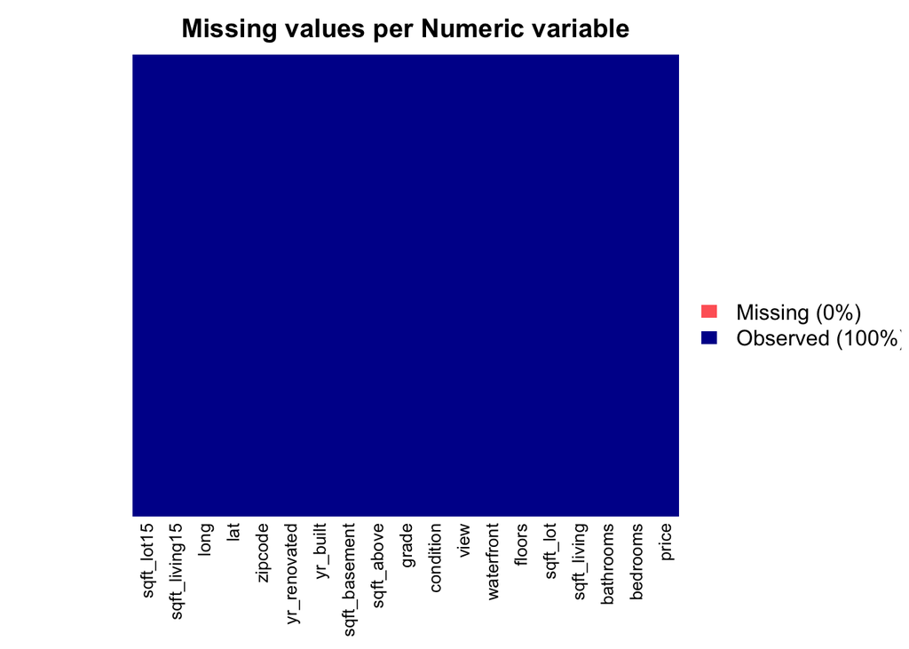

```r
numcols <- select_if(house_price, is.numeric)
missmap(numcols, y.labels = NULL, y.at = NULL,
        main = 'Missing values per Numeric variable', rank.order = TRUE,
        col = c(MissingColor, HBarFillColor)) #No missing values in Numeric variables
```

We plot a Missings map for Categorical variables. The absence of missing values is confirmed.

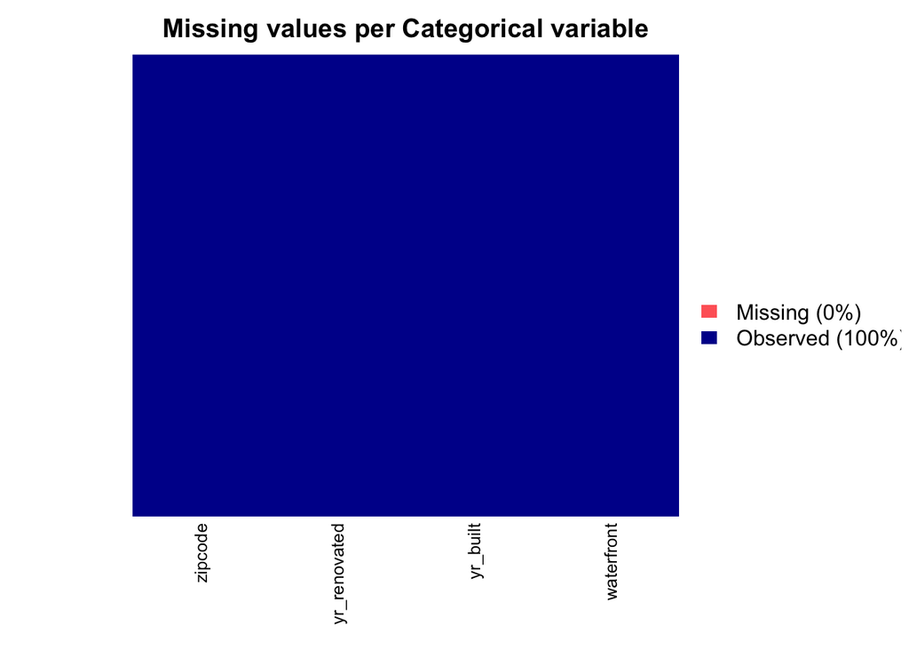

```r
catcols <- c("waterfront","yr_built","yr_renovated","zipcode")
house_price[,catcols] <- data.frame(apply(house_price[catcols], 2, as.factor))
missmap(house_price[,catcols], y.labels = NULL, y.at = NULL,
        main = 'Missing values per Categorical variable', rank.order = TRUE,
        col = c(MissingColor, HBarFillColor)) #No missing values in Categorical variables
```

## Baseline Model

We train a baseline model using all the features as they are, with no further treatment or selection criteria.

```r
set.seed(1234)
index <- createDataPartition(house_price$waterfront,p=0.8,list=FALSE)
#Split dataset in Train (80%) and Test (20%)
house_train <- house_price[index,]
house_test <- house_price[-index,]

#kfolds
kfolds <- trainControl(method = "cv", number = 10, savePredictions=TRUE)

#Train baseline model
baseline_model <- train(price~.,data=house_train, method="lm", trControl = kfolds)

#Print Model Results
print(baseline_model)
```

```
## Linear Regression
##
## 13740 samples
##    18 predictor
##
## No pre-processing
## Resampling: Cross-Validated (10 fold)
## Summary of sample sizes: 12365, 12366, 12366, 12366, 12367, 12365, ...
## Resampling results:
##
##   RMSE      Rsquared   MAE
##   162840.3  0.8085596  97999.18
##
## Tuning parameter 'intercept' was held constant at a value of TRUE
```

Baseline Model Predictions vs Validation Set:

```r
#Baseline Model predictions
val_baseline <- predict(baseline_model,house_test)
paste("MAPE: ", mape(real=house_test$price, predicted = val_baseline)*100,"%",sep = '')
```

```
## [1] "MAPE: 20.2252239813206%"
```

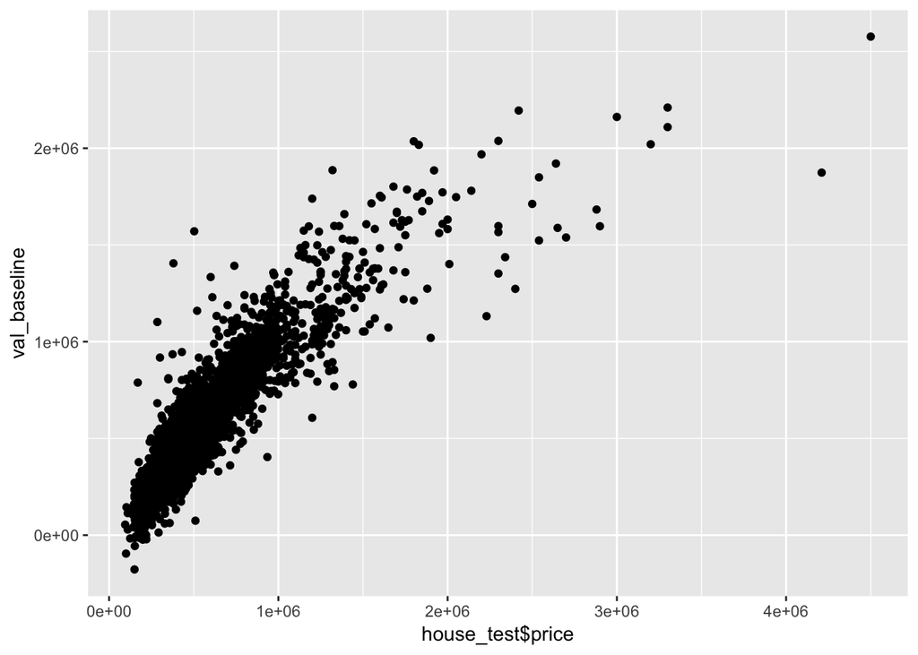

```r
qplot(house_test$price, val_baseline)
```

This Baseline model produces an R-square of 80% and a Mean Absolute Percentage Error (from now on MAPE) of 20.2%.

In order to improve our predictions it is necessary to treat each one of the variables, create new features (if necessary), check if correlation between variables exists, etc. This process is described in the following steps.

# Feature Engineering

## Variable Treatment: Outliers

### Numeric Variables

Boxplots for each Numeric variable are presented.

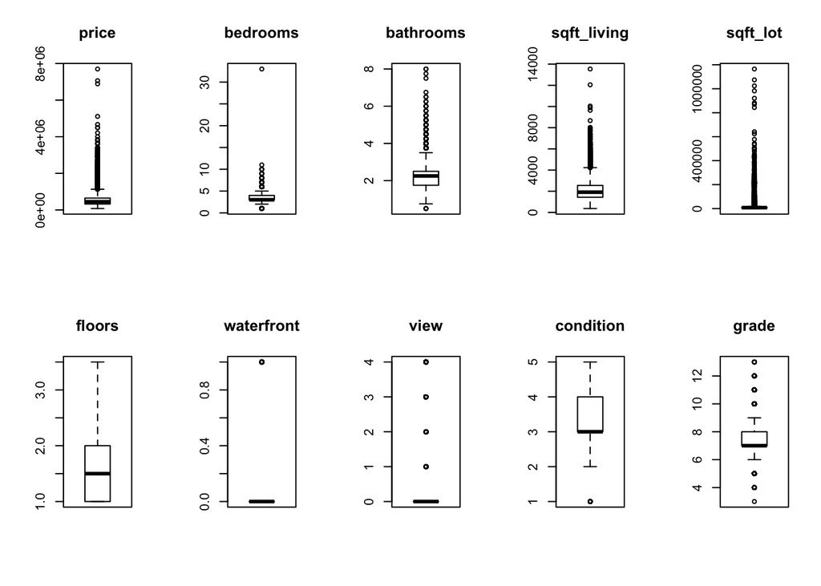

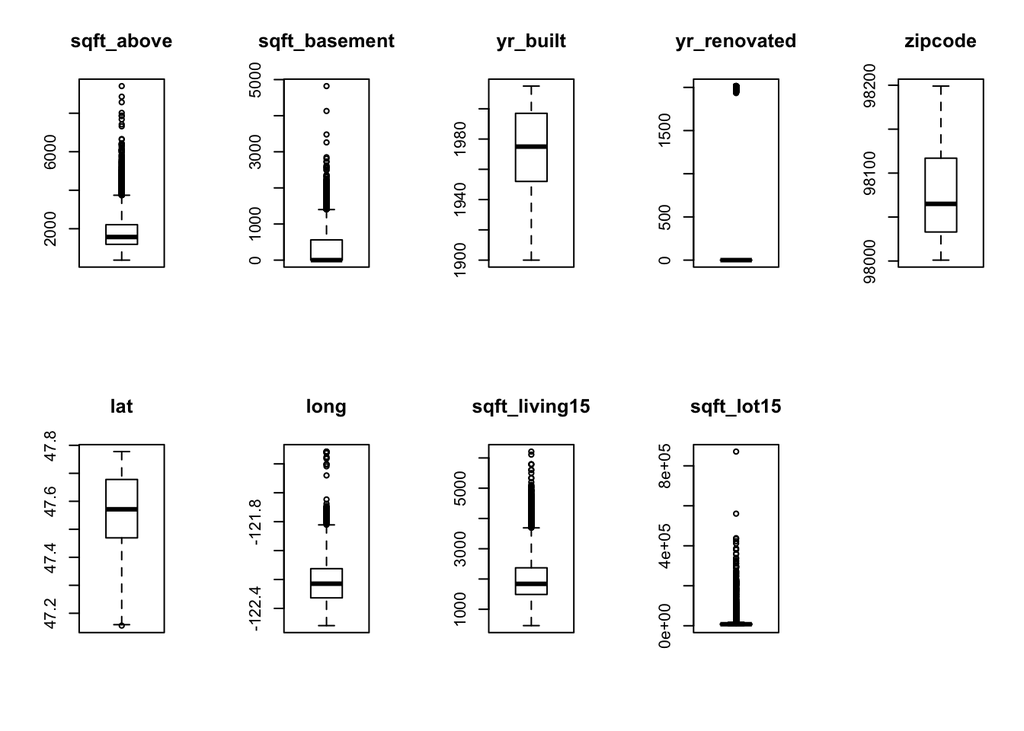

```r
par(mfrow=c(2,5))
for(i in 1:ncol(numcols)) {
  boxplot(numcols[,i], main=names(numcols)[i])
}
```

Variables such as ‘bedrooms’, ‘bathrooms’, ‘sqft_living’, ‘sqft_lot’, ‘sqft_above’, ‘sqft_basement’, ‘sqft_living15’ and ‘sqft_lot15’ contain outliers. These variables will be treated capping outliers equal or bigger than the 95th percentile value and equal or smaller than the 5th percentile value. Variables which depict location such as ‘lat’, ‘long’ will be kept untreated.

A function was previosuly defined to cap outliers (Refer to section ‘Configuring Global Variables and Functions’) and it is executed for every Numeric variable mentioned above.

```r
house_price$bedrooms_t <- outlier_treatment(house_price$bedrooms)
house_price$bathrooms_t <- outlier_treatment(house_price$bathrooms)
house_price$sqft_living_t <- outlier_treatment(house_price$sqft_living)
house_price$sqft_lot_t <- outlier_treatment(house_price$sqft_lot)
house_price$sqft_above_t <- outlier_treatment(house_price$sqft_above)
house_price$sqft_living15_t <- outlier_treatment(house_price$sqft_living15)
house_price$sqft_lot15_t <- outlier_treatment(house_price$sqft_lot15)
house_price$grade_t <- outlier_treatment(house_price$grade)
```

Variables ‘sqft_basement’ and ‘view’ will be transformed to Categorical variables (flag variables with values 0 or 1) due to the large proportion of values equal to 0.

```r
house_price$basement <- ifelse(house_price$sqft_basement == 0, 0, 1)
house_price$fview <- ifelse(house_price$view == 0, 0, 1)
```

### Categorical variables

Barplots for each Categorical variable are presented.

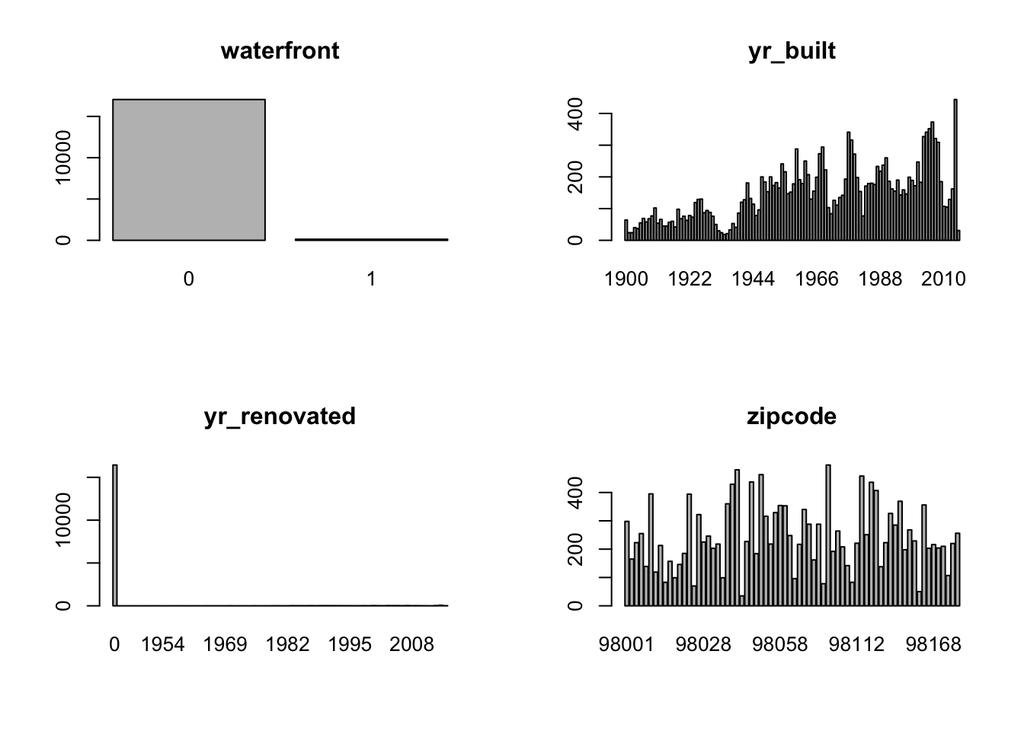

```r
par(mfrow=c(2,2))
for(i in 1:length(catcols)) {
  counts <- table(house_price[,catcols][,i])
  name <- names(house_price[,catcols])[i]
  barplot(counts, main=name)
}
```

Variable ‘yr_renovated’ will be transformed to a flag variable with values 0 or 1 due to the large proportion of values equal to 0. Variable ‘yr_built’ is transformed to ‘houseAge’ (Numeric variable) representing number of years since the house was built.

```r
house_price$renovated <- ifelse(house_price$yr_renovated == 0, 0, 1)
house_price$houseAge <- as.integer(format(Sys.Date(), "%Y")) - as.integer(as.character(house_price$yr_built))
```

After variable treatment and creation of new features, we keep the transformed variables and plot them again to check their new distribution.

```r
catcols <- c(catcols,"fview","renovated", "basement")
house_price[,catcols] <- data.frame(apply(house_price[catcols], 2, as.factor))
```

```r
rm_col <- c("bedrooms","bathrooms","sqft_living","sqft_lot","sqft_above",
            "sqft_basement","sqft_living15",
            "sqft_lot15","grade","view")
house_price1 <- house_price[, !(colnames(house_price) %in% rm_col), drop = FALSE]
numcols <- select_if(house_price1, is.numeric)
```

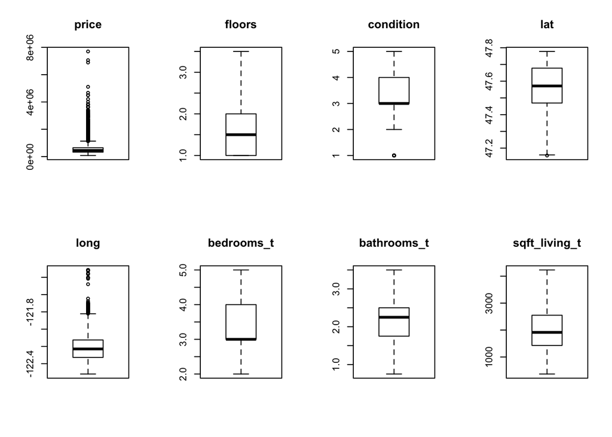

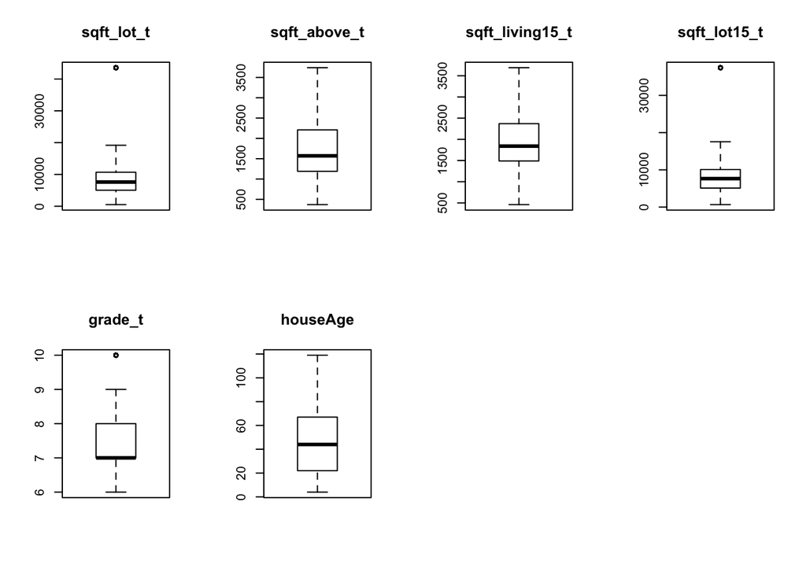

```r
par(mfrow=c(2,4))
for(i in 1:ncol(numcols)) {
  boxplot(numcols[,i], main=names(numcols)[i])
}
```

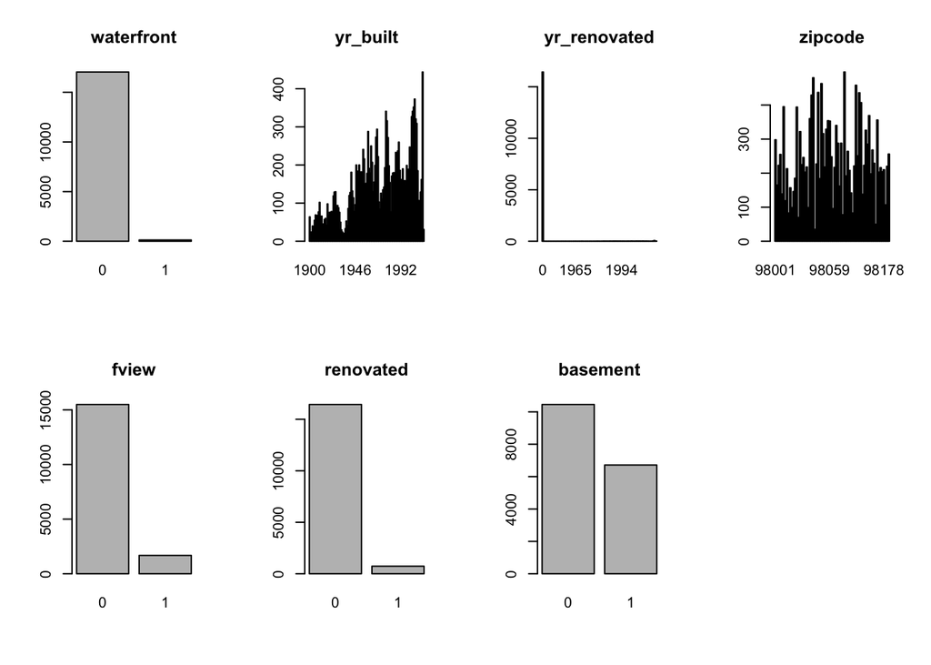

```r
par(mfrow=c(2,4))
for(i in 1:length(catcols)) {
  counts <- table(house_price1[,catcols][,i])
  name <- names(house_price1[,catcols])[i]
  barplot(counts, main=name)
}
```

### Correlation Analysis

A correlation analysis is presented to identify which variables are highly correlated in order to not include them in our models at the same time.

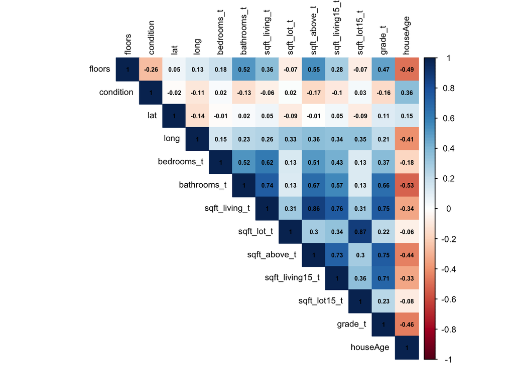

```r
#Select all variables minus Target variable
house_price2 <- subset(house_price1, select = -c(price))
#Plot Correlation Matrix
CorrelationResults <- cor(select_if(house_price2, is.numeric))
corrplot(CorrelationResults,method="color", type='upper',addCoef.col = "black",
        number.cex = 0.5, tl.col = "black", tl.cex = 0.7, cl.cex = 0.7)
```

### Variable Scaling

Due to the different scales in our Numeric variables (‘sqft’ variables representing thousands and ‘bedrooms’ and/or ‘bathrooms’ representing units) it is necessary to scale all Numeric variables so each get the same ‘weight’ when models are built.

```r
house_price1$sqft_living_tf <- scale(house_price1$sqft_living_t)
house_price1$sqft_lot_tf <- scale(house_price1$sqft_lot_t)
house_price1$houseAge_f <- scale(house_price1$houseAge)
house_price1$bathrooms_tf <- scale(house_price1$bathrooms_t)
house_price1$bedrooms_tf <- scale(house_price1$bedrooms_t)
house_price1$floors_f <- scale(house_price1$floors)
house_price1$condition_f <- scale(house_price1$condition)
house_price1$grade_tf <- scale(house_price1$grade_t)
```

## Variable Selection

Finally we select the most updated version of each variable (i.e. treated for outliers and/or scaled), taking into account not to select two highly correlated variables. Variable ‘zipcode’ is discarded as it presents a large number of levels and contributes approximately ‘similar’ information as ‘lat’ and ‘long’.

```r
keep_col <- c("price","grade_tf","sqft_living_tf","sqft_lot_tf","renovated",
              "basement","houseAge_f","bathrooms_tf","bedrooms_tf","floors_f",
              "waterfront","fview","lat", "long","condition_f")
house_price3 <- house_price1[, (colnames(house_price1) %in% keep_col)]

house_train3 <- house_price3[index,]
house_test3 <- house_price3[-index,]
```

# Modelling

## Linear Regression

```r
model_lm <- train(price~.,data=house_train3, method="lm", trControl = kfolds)
print(model_lm)
```

```
## Linear Regression
##
## 13740 samples
##    14 predictor
##
## No pre-processing
## Resampling: Cross-Validated (10 fold)
## Summary of sample sizes: 12365, 12366, 12366, 12366, 12366, 12367, ...
## Resampling results:
##
##   RMSE      Rsquared   MAE
##   226356.6  0.6279451  132759.8
##
## Tuning parameter 'intercept' was held constant at a value of TRUE
```

**Linear Regression Predictions vs Validation Set:**

```r
# Prediction
val_lm <- predict(model_lm,house_test3)
paste("MAPE: ", mape(real=house_test3$price, predicted = val_lm)*100,"%",sep = '')
```

```
## [1] "MAPE: 26.396209157554%"
```

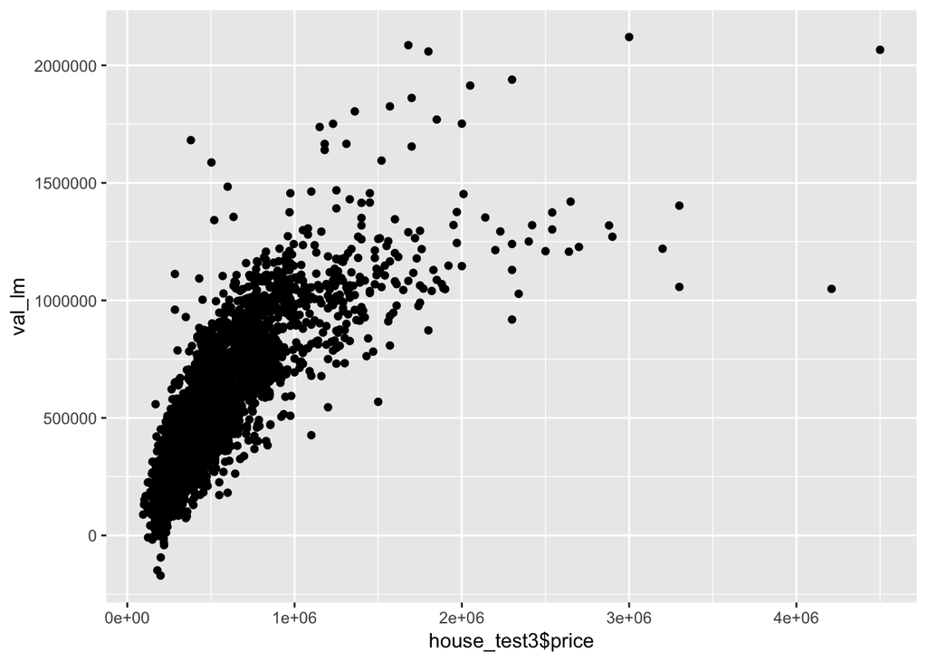

```r
qplot(house_test3$price, val_lm)
```

## Random Forest

```r
# Define grid of hyperparameters to tune
tuneGrid=data.table(expand.grid(mtry=c(5,14),
                                splitrule='variance',
                                min.node.size=c(2,5,10)))

model_rf <- train(price~.,data=house_train3, method="ranger",
                num.trees=500,
                preProc = NULL,
                tuneGrid = tuneGrid,
                trControl = kfolds,
                metric = "MAE")
print(model_rf)
```

```
## Random Forest
##
## 13740 samples
##    14 predictor
##
## No pre-processing
## Resampling: Cross-Validated (10 fold)
## Summary of sample sizes: 12366, 12366, 12365, 12364, 12365, 12366, ...
## Resampling results across tuning parameters:
##
##   mtry  min.node.size  RMSE      Rsquared   MAE
##    5     2             142588.7  0.8528822  72781.94
##    5     5             142580.7  0.8528622  72926.52
##    5    10             143376.0  0.8516276  73220.82
##   14     2             142269.6  0.8532239  72103.83
##   14     5             142443.6  0.8530188  72109.87
##   14    10             142316.5  0.8530141  72206.21
##
## Tuning parameter 'splitrule' was held constant at a value of variance
## MAE was used to select the optimal model using the smallest value.
## The final values used for the model were mtry = 14, splitrule =
##  variance and min.node.size = 2.
```

**Random Forest Predictions vs Validation Set:**

```r
# Prediction
val_rf <- predict(model_rf,house_test3)
paste("MAPE: ", mape(real=house_test3$price, predicted = val_rf)*100,"%",sep = '')
```

```
## [1] "MAPE: 13.1330895462681%"
```

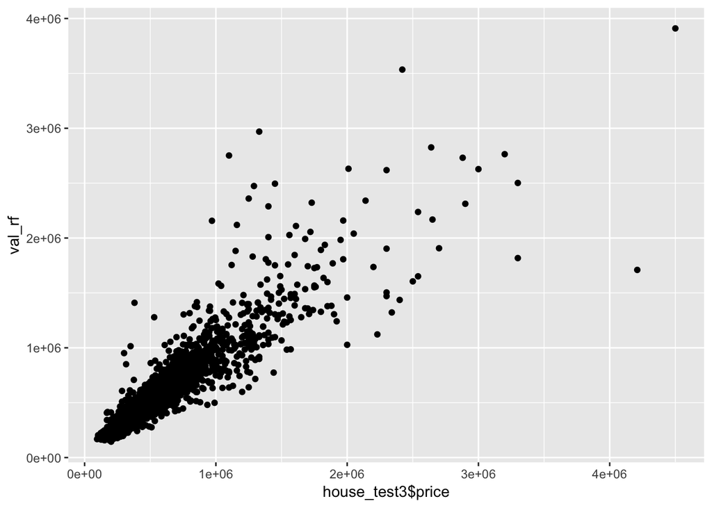

```r
qplot(house_test3$price, val_rf)
```

## Gradient Boosting

```r
model_gbm <- train(price~.,data=house_train3, method="gbm",
                trControl = kfolds,
                verbose = F)

print(model_gbm)
```

[output not shown]

**GBM Predictions vs Validation Set:**

```r
# Prediction
val_gbm <- predict(model_gbm,house_test3)
paste("MAPE: ", mape(real=house_test3$price, predicted = val_gbm)*100,"%",sep = '')
```

```
## [1] "MAPE: 15.5815081836281%"
```

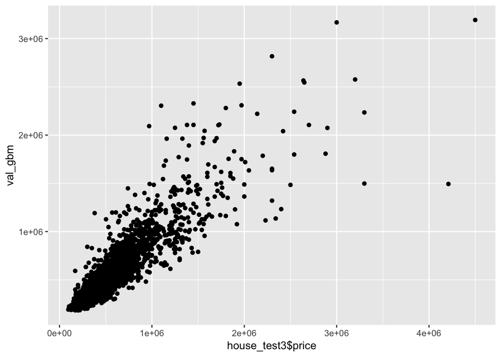

```r
qplot(house_test3$price, val_gbm)
```

## Extreme Gradient Boosting (XGB)

```r
xgbGrid <- expand.grid(nrounds = 500,
                       max_depth = 4,
                      eta = .05,
                       gamma = 0,
                       colsample_bytree = .5,
                       min_child_weight = 1,
                       subsample = 1)

model_xgb<- train(price~.,data=house_train3, method="xgbTree", trControl=kfolds,
                  tuneGrid = xgbGrid, na.action = na.pass,
                  metric = "MAE")
print(model_xgb)
```

[output not shown]

**XGB Predictions vs Validation Set:**

```r
# Prediction
val_xgb <- predict(model_xgb,house_test3)
paste("MAPE: ", mape(real=house_test3$price, predicted = val_xgb)*100,"%",sep = '')
```

```
## [1] "MAPE: 13.2875411614184%"
```

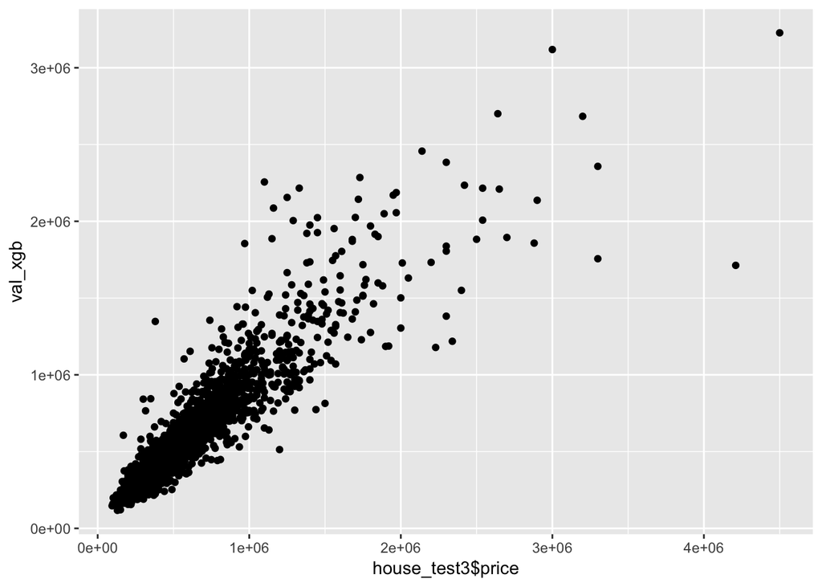

```r
qplot(house_test3$price, val_xgb)
```

## XGB + Principal Components Analysis (Latitude and Longitude)

A PC analysis is performed on variables ‘lat’ and ‘long’ and the new Pricipal Components are tested in the XGB model.

### PC Analysis

```r
# Principal Components Analysis
PCAData = house_price3 %>%
  select(lat,long)
pca = prcomp(PCAData, scale. = T)
pca_temp <- predict(pca, newdata = PCAData)
pca_temp = as.data.frame(pca_temp)

house_price3_pca = cbind(house_price3,pca_temp)
house_price3_pca$lat = NULL
house_price3_pca$long = NULL
```

```r
house_train3_pca <- house_price3_pca[index,]
house_test3_pca <- house_price3_pca[-index,]
```

### XGB + PCA

```r
model_xgb_pca = train(price~.,data=house_train3_pca,
                   method = "xgbTree",trControl = kfolds,
                   tuneGrid = xgbGrid,na.action = na.pass,metric="MAE")

print(model_xgb_pca)
```

```
## eXtreme Gradient Boosting
##
## 13740 samples
##    14 predictor
##
## No pre-processing
## Resampling: Cross-Validated (10 fold)
## Summary of sample sizes: 12366, 12367, 12365, 12365, 12365, 12366, ...
## Resampling results:
##
##   RMSE      Rsquared   MAE
##   140738.1  0.8574789  75730.34
##
## Tuning parameter 'nrounds' was held constant at a value of 500
##  0.5
## Tuning parameter 'min_child_weight' was held constant at a value of
##  1
## Tuning parameter 'subsample' was held constant at a value of 1
```

```r
#### Prediction
val_xgb_pca <- predict(model_xgb_pca,house_test3_pca)
paste("MAPE: ", mape(real=house_test3_pca$price, predicted = val_xgb_pca)*100,"%",sep = '')
```

```
## [1] "MAPE: 14.0385916365074%"
```

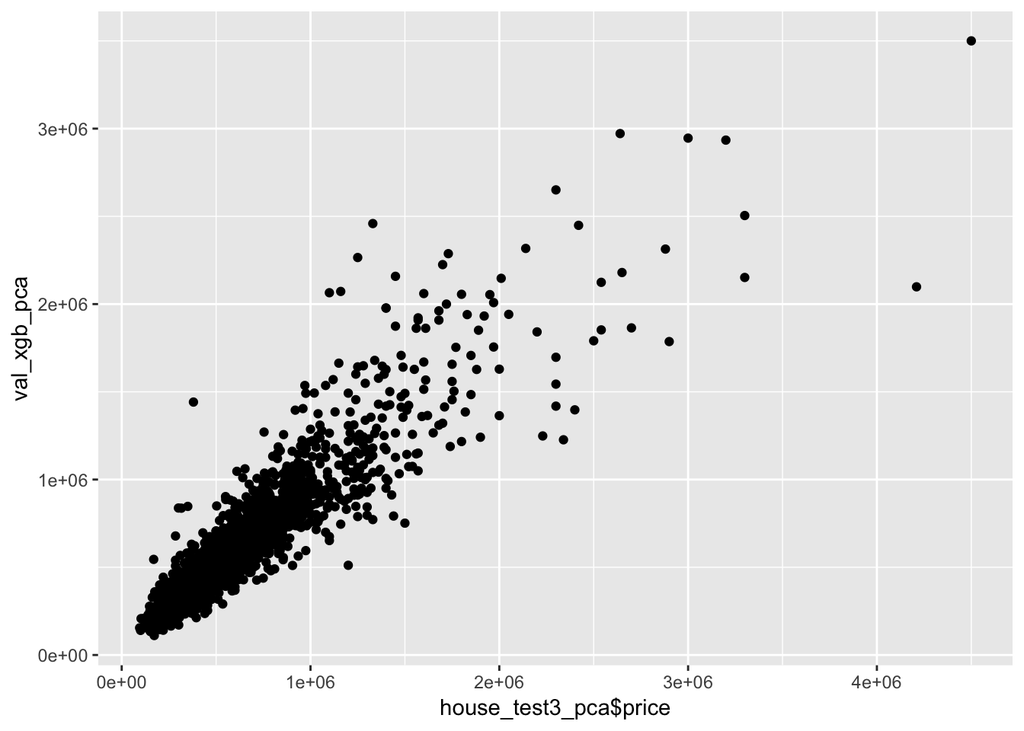

```r
qplot(house_test3_pca$price, val_xgb_pca)
```

# Modeling with Log(Price) as Target

Distribution of House Price (Target variable) is right skewed, so a log() function is applied and all models are re-trained.

## Log(Price)

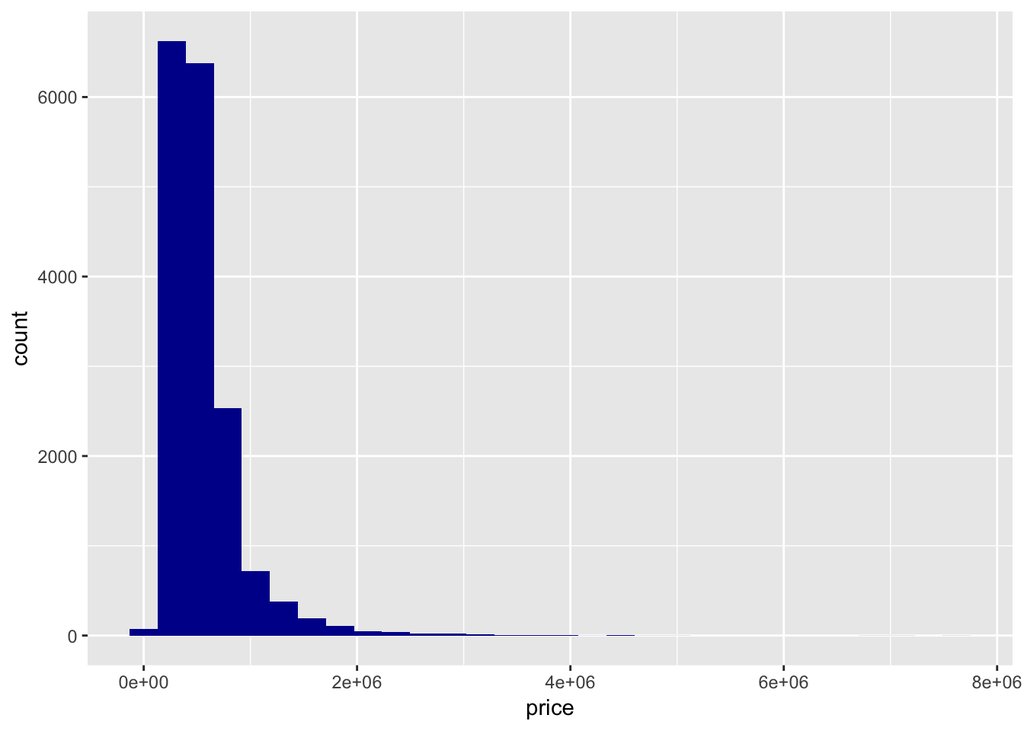

```r
temp_price <-house_price3 %>%
             select(price)
ggplot(temp_price,aes(x=price)) + geom_histogram(fill=HBarFillColor)
```

After transforming price into log(price)

```r
house_price3_logp <- house_price3
house_price3_logp$logprice <- log(house_price3_logp$price)
house_price3_logp$price <- NULL

house_train3_logp <- house_price3_logp[index,]
house_test3_logp <- house_price3_logp[-index,]
```

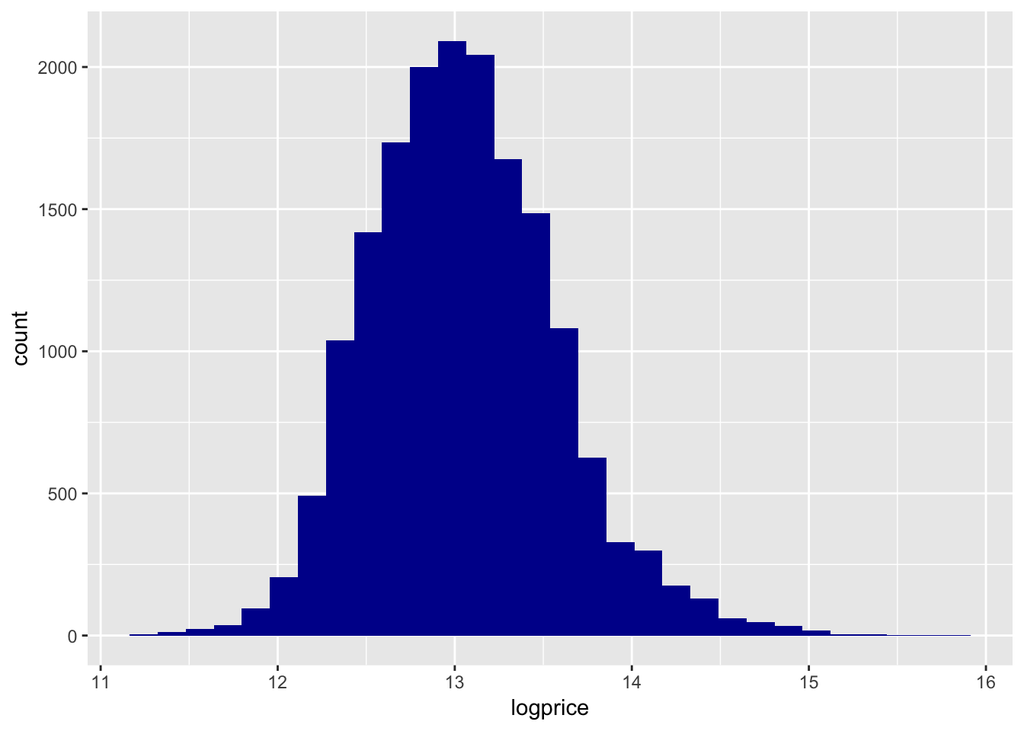

```r
temp_price <-house_price3_logp %>%
             select(logprice)
ggplot(temp_price,aes(x=logprice)) + geom_histogram(fill=HBarFillColor)
```

## Random Forest (Log(Price))

```r
#RF - Log Price
model_rf_logp <- train(logprice~.,data=house_train3_logp, method="ranger",
                num.trees=500,
                preProc = NULL,
                tuneGrid = tuneGrid,
                trControl = kfolds,
                metric = "MAE")
print(model_rf_logp)
```

```
## Random Forest
##
## 13740 samples
##    14 predictor
##
## No pre-processing
## Resampling: Cross-Validated (10 fold)
## Summary of sample sizes: 12365, 12365, 12365, 12365, 12367, 12367, ...
## Resampling results across tuning parameters:
##
##   mtry  min.node.size  RMSE       Rsquared   MAE
##    5     2             0.1786627  0.8854554  0.1261995
##    5     5             0.1787194  0.8854576  0.1263431
##    5    10             0.1794960  0.8846388  0.1270330
##   14     2             0.1801259  0.8828632  0.1267810
##   14     5             0.1799321  0.8830989  0.1267108
##   14    10             0.1802216  0.8827511  0.1269999
##
## Tuning parameter 'splitrule' was held constant at a value of variance
## MAE was used to select the optimal model using the smallest value.
## The final values used for the model were mtry = 5, splitrule =
##  variance and min.node.size = 2.
```

**RF - Log(Price) Predictions vs Validation Set:**

```r
# Prediction
val_rf_logp <- predict(model_rf_logp,house_test3_logp)
paste("MAPE: ", mape(real=exp(house_test3_logp$logprice),
                     predicted = exp(val_rf_logp))*100,"%",sep = '')
```

```
## [1] "MAPE: 12.6063988567519%"
```

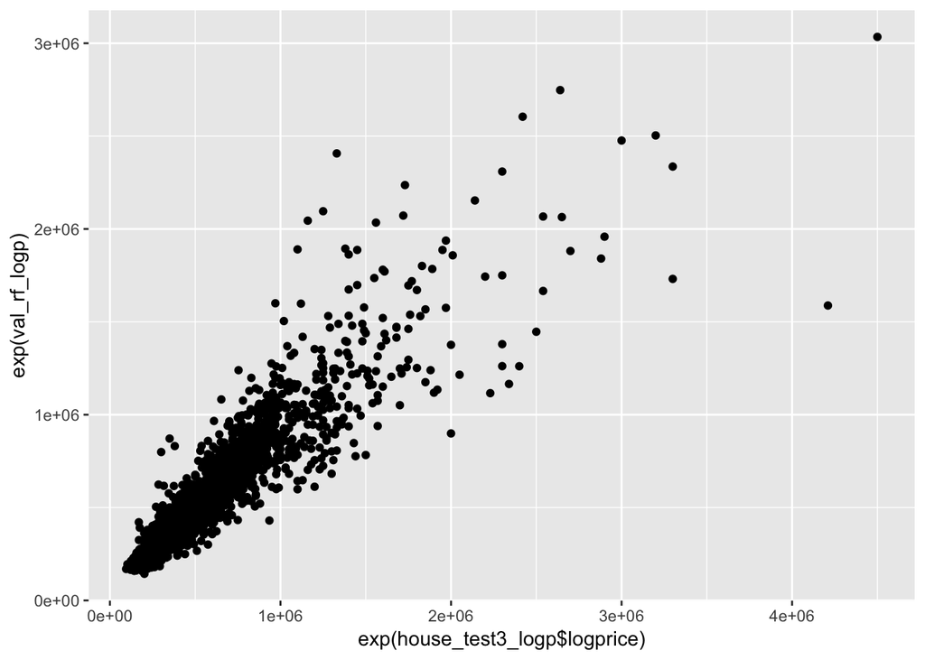

```r
qplot(exp(house_test3_logp$logprice), exp(val_rf_logp))
```

## Gradient Boosting (Log(Price))

```r
# GBM - Log Price
model_gbm_logp <- train(logprice~.,data=house_train3_logp, method="gbm",
                trControl = kfolds, verbose = F)

print(model_gbm_logp)
```

[output not shown]

**GBM - Log(Price) Predictions vs Validation Set:**

```r
# Prediction
val_gbm_logp <- predict(model_gbm_logp,house_test3_logp)
paste("MAPE: ", mape(real=exp(house_test3_logp$logprice),
                     predicted = exp(val_gbm_logp))*100,"%",sep = '')
```

```
## [1] "MAPE: 14.4407120157877%"
```

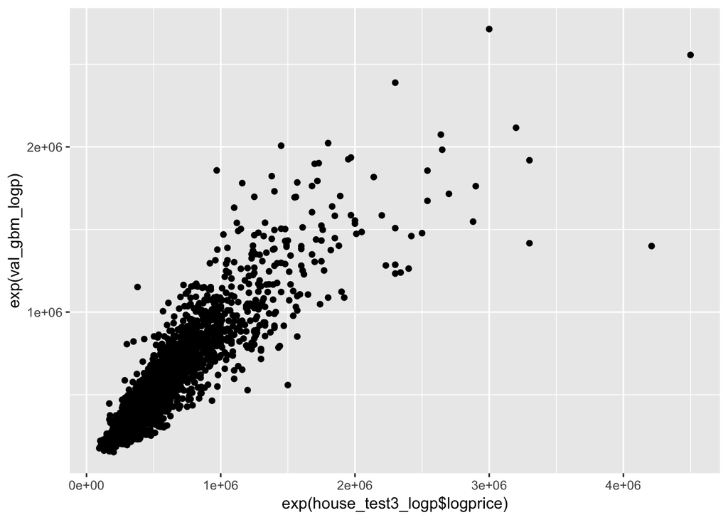

```r
qplot(exp(house_test3_logp$logprice), exp(val_gbm_logp))
```

## XGB (Log(Price))

```r
# XGB - Log Price
model_xgb_logp <- train(logprice~.,data=house_train3_logp, method="xgbTree", trControl=kfolds,
                  tuneGrid = xgbGrid, na.action = na.pass,
                  metric = "MAE")

print(model_xgb_logp)
```

[output not shown]

**XGB - Log(Price) Predictions vs Validation Set:**

```r
# Prediction
val_xgb_logp <- predict(model_xgb_logp,house_test3_logp)
paste("MAPE: ", mape(real=exp(house_test3_logp$logprice),
                     predicted = exp(val_xgb_logp))*100,"%",sep = '')
```

```
## [1] "MAPE: 12.3789767122238%"
```

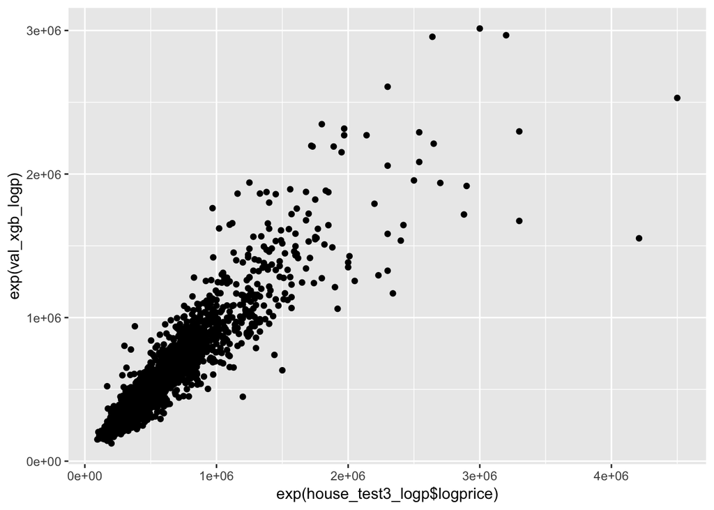

```r
qplot(exp(house_test3_logp$logprice), exp(val_xgb_logp))
```

## XGB + PCA (Log(Price))

```r
## PCA
PCAData = house_price3_logp %>%
  select(lat,long)
pca = prcomp(PCAData, scale. = T)
pca_temp <- predict(pca, newdata = PCAData)
pca_temp = as.data.frame(pca_temp)
house_price3_logp_pca = cbind(house_price3_logp,pca_temp)
house_price3_logp_pca$lat = NULL
house_price3_logp_pca$long = NULL
```

```r
house_train3_logp_pca <- house_price3_logp_pca[index,]
house_test3_logp_pca <- house_price3_logp_pca[-index,]
```

```r
model_xgb_logp_pca = train(logprice~.,data=house_train3_logp_pca,
                   method = "xgbTree",trControl = kfolds,
                   tuneGrid = xgbGrid,na.action = na.pass,metric="MAE")

print(model_xgb_logp_pca)
```

```
## eXtreme Gradient Boosting
##
## 13740 samples
##    14 predictor
##
## No pre-processing
## Resampling: Cross-Validated (10 fold)
## Summary of sample sizes: 12367, 12366, 12365, 12366, 12366, 12367, ...
## Resampling results:
##
##   RMSE       Rsquared   MAE
##   0.1787696  0.8847943  0.1290985
##
## Tuning parameter 'nrounds' was held constant at a value of 500
##  0.5
## Tuning parameter 'min_child_weight' was held constant at a value of
##  1
## Tuning parameter 'subsample' was held constant at a value of 1
```

**XGB + PCA - Log(Price) Predictions vs Validation Set:**

```r
# Prediction
val_xgb_logp_pca <- predict(model_xgb_logp_pca,house_test3_logp_pca)
paste("MAPE: ", mape(real=exp(house_test3_logp_pca$logprice),
                     predicted = exp(val_xgb_logp_pca))*100,"%",sep = '')
```

```
## [1] "MAPE: 13.2868593524592%"
```

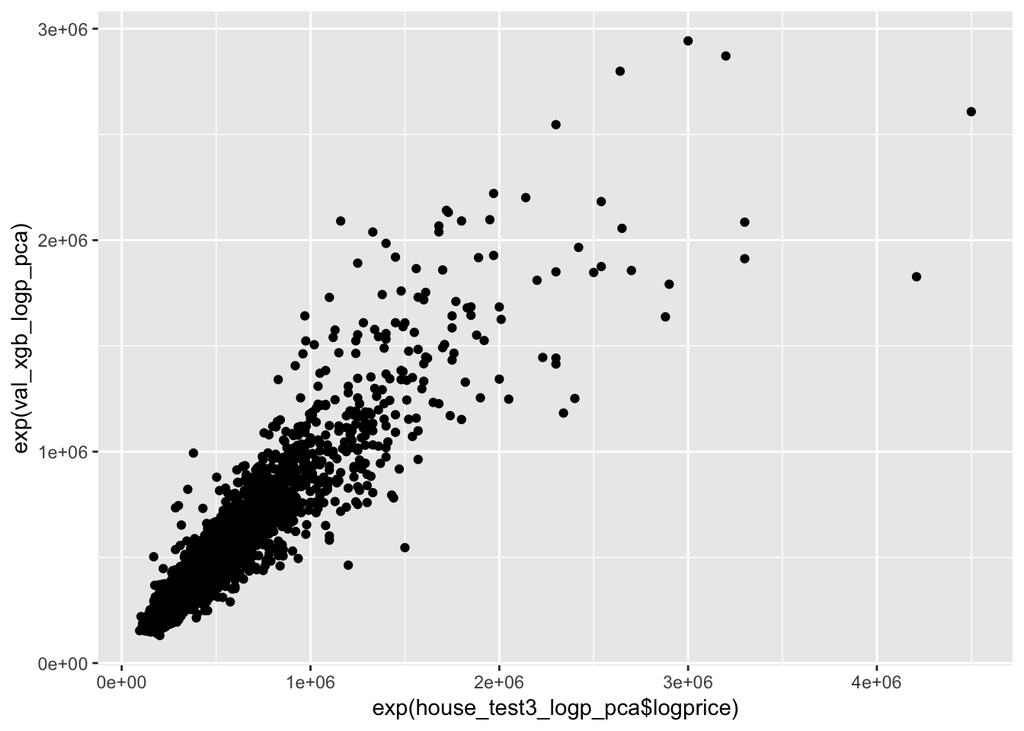

```r
qplot(exp(house_test3_logp_pca$logprice), exp(val_xgb_logp_pca))
```

# Model Selection

# Next Steps

## Test Set preparation

The Test set that we left out of the Training phase needs to be prepared to receive our model. That means, we need to treat its variables on the same fashion we did on the Training dataset. This process is documented in the Predicting_TestSet.R file attached.